# Visualization with `GGPlot`

## Stepwise Creation of a Plot

Adding a Geometry Layer

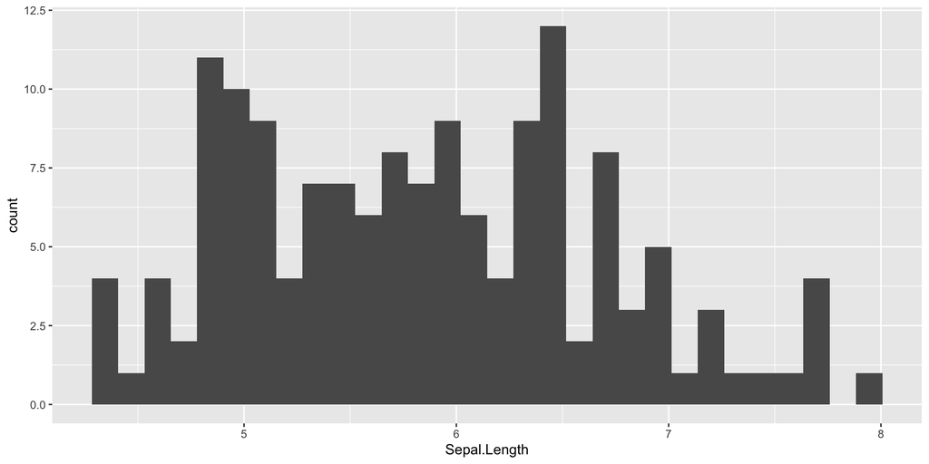

```r
ggplot( iris, aes( x = Sepal.Length) ) +
  geom_histogram()
```

## Stepwise Creation of a Density Plot

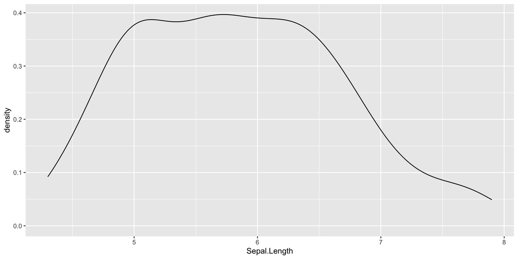

```r
ggplot( iris, aes( x = Sepal.Length) ) +
  geom_density()
```

## A Scatter Plot

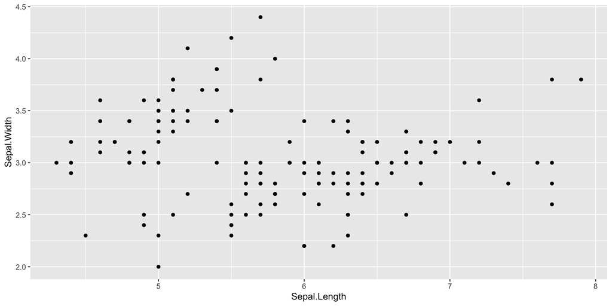

```r
ggplot( iris, aes( x = Sepal.Length, y = Sepal.Width) ) + geom_point()
```

## Scatterplot with Colors

*Aesthetics* also contribute to symbologies and colors

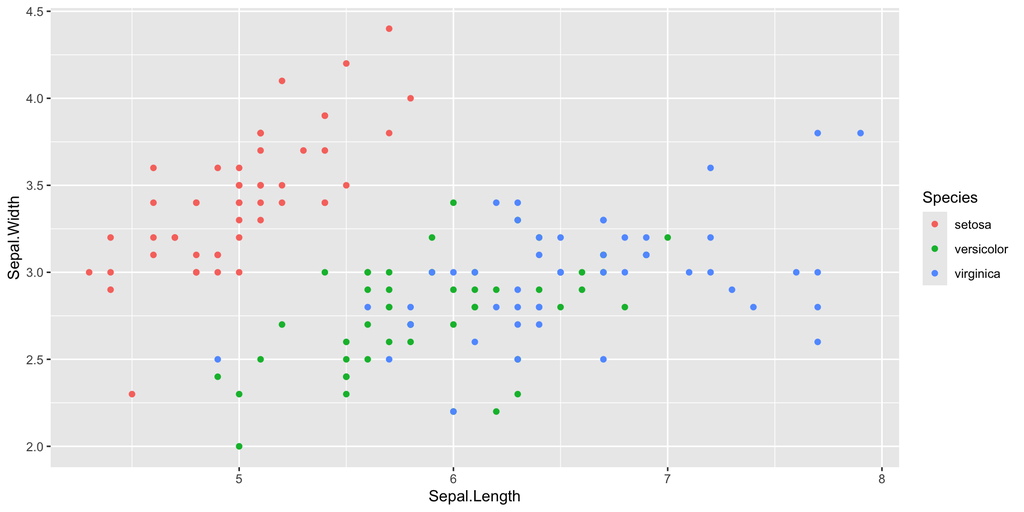

```r
ggplot( iris, aes( x = Sepal.Length,
                   y = Sepal.Width,
                   color=Species) ) +
  geom_point()
```

## In & Out of `aes()`

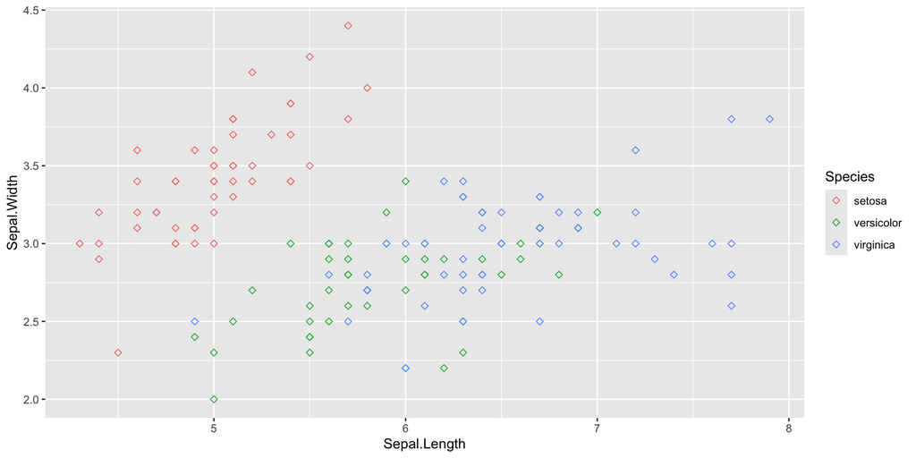

```r
ggplot( iris ) +
  geom_point(aes( x = Sepal.Length, y = Sepal.Width, col=Species), shape=5)
```

## Iterative Building of Graphics

```r
p <- ggplot( iris )
p <- p + geom_point( aes( x = Sepal.Length,
                          y = Sepal.Width,
                          col=Species,
                          shape=Species),
                     size=3,
                     alpha=0.75 )
p <- p + xlab("Sepal Length")
p <- p + ylab("Sepal Length")
class(p)
```

```
[1] "gg"     "ggplot"
```

## Printing out `p`

```r
p
```

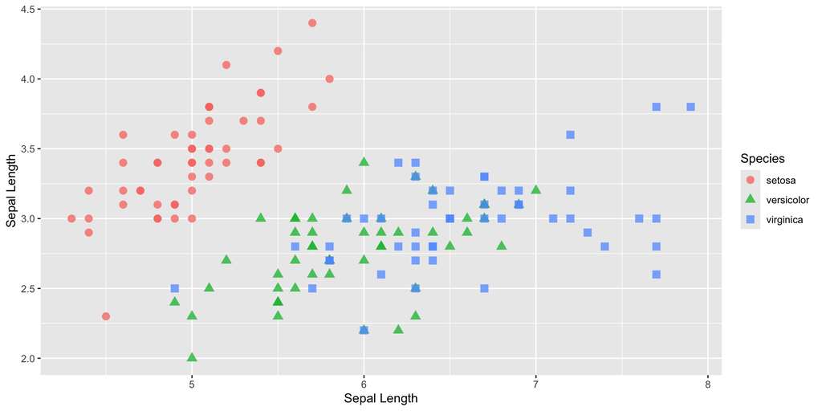

## Scope of Visibility

Only things in `ggplot()` apply to *all* following components. Placing `aes()` or `data=` parts in later components *only* make them visible to that particular component.

```r
ggplot( iris, aes( x = Sepal.Length, y = Sepal.Width) ) +
  geom_point() +
  stat_smooth()
```

```r
ggplot( iris ) +
  geom_point( aes( x = Sepal.Length, y = Sepal.Width) ) +
  stat_smooth(  aes( x = Sepal.Length, y = Sepal.Width) )
```

```r
ggplot() +
  geom_point( aes( x = Sepal.Length, y = Sepal.Width), data = iris )  +
  stat_smooth( aes( x = Sepal.Length, y = Sepal.Width), data = iris )
```

# Themes

# Customizable!!!

```r
p + theme_bw()
```

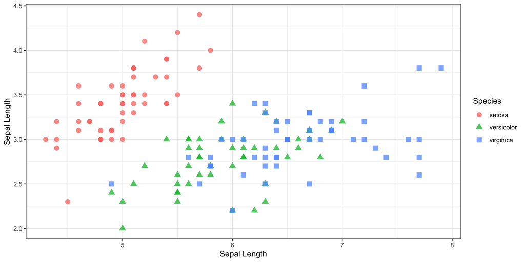

```r
p + theme_bw()
```

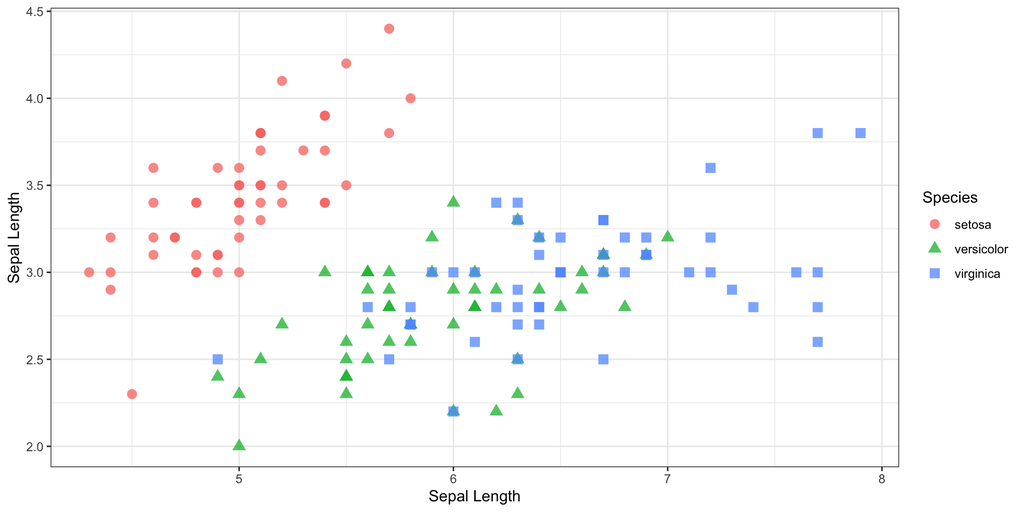

```r
p + theme_gray()
```

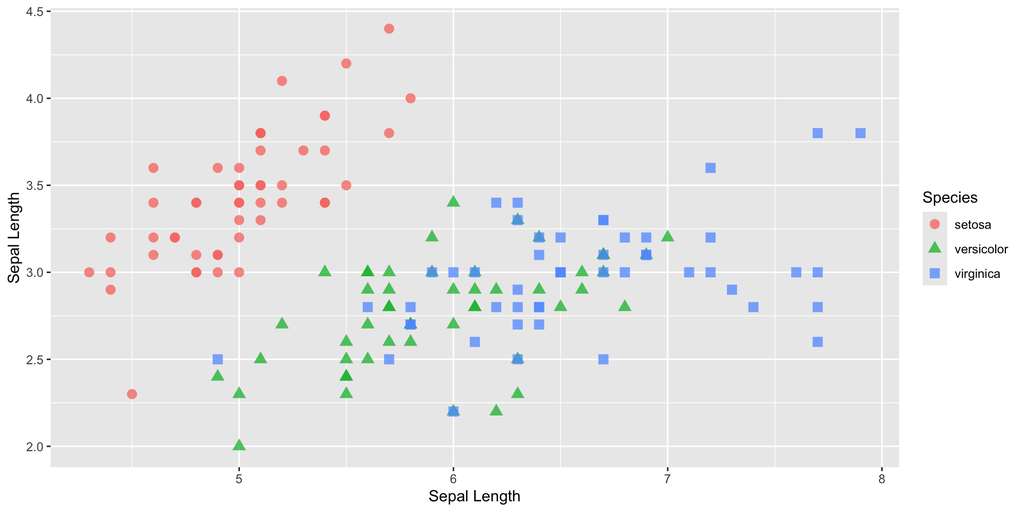

```r
p + theme_linedraw()
```

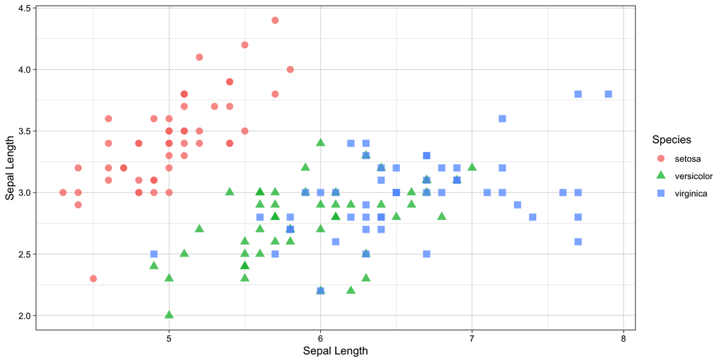

```r
p + theme_dark()
```

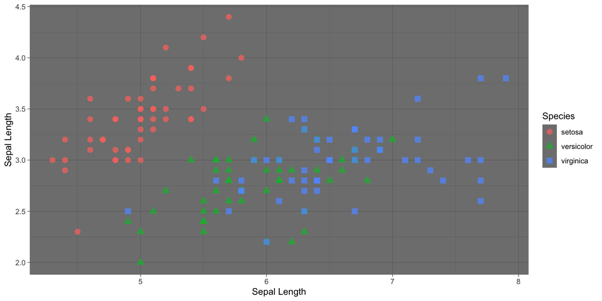

```r
p + theme_minimal()
```

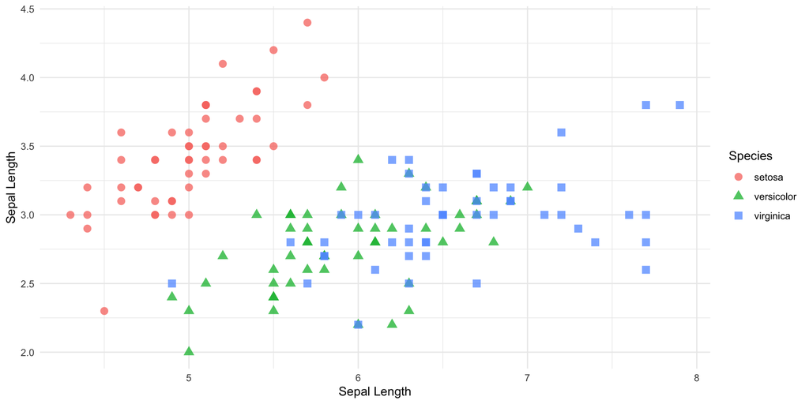

```r
p + theme_classic()
```

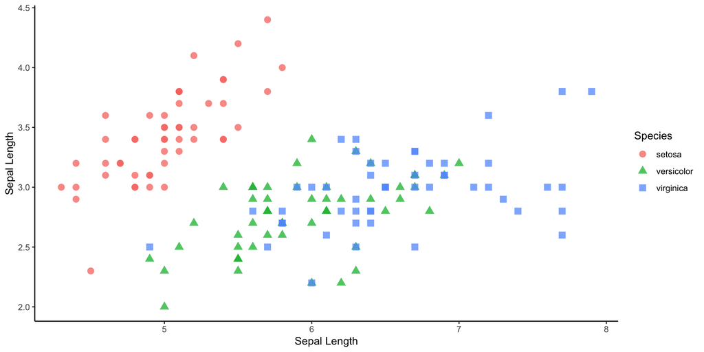

```r
p + theme_void()
```

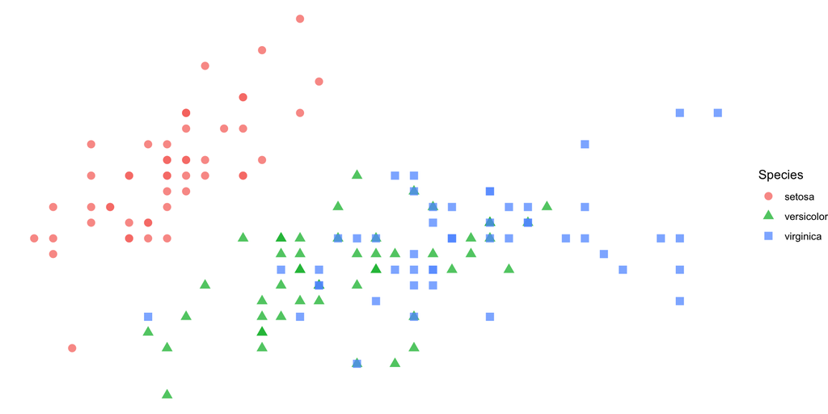

## Create Your Own Themes

```r
source("theme_dyerlab_grey.R")
theme_dyerlab_grey
```

```
function (base_size = 18, base_family = "")
{
    theme_grey(base_size = base_size, base_family = base_family) %+replace%
        theme(axis.line = element_blank(), axis.text.x = element_text(size = base_size *
            0.8, color = "white", lineheight = 0.9), axis.text.y = element_text(size = base_size *
            0.8, color = "white", lineheight = 0.9), axis.ticks = element_line(color = "white",
            size = 0.2), axis.title.x = element_text(size = base_size,
            color = "white", margin = margin(0, 10, 0, 0)), axis.title.y = element_text(size = base_size,
            color = "white", angle = 90, margin = margin(0, 10,
                0, 0)), axis.ticks.length = unit(0.3, "lines"),
            legend.background = element_rect(color = NA, fill = "#272822"),
            legend.key = element_rect(color = "white", fill = "#272822"),
            legend.key.size = unit(1.2, "lines"), legend.key.height = NULL,
            legend.key.width = NULL, legend.text = element_text(size = base_size *
                0.8, color = "white"), legend.title = element_text(size = base_size *
                0.8, face = "bold", hjust = 0, color = "white"),
            legend.position = "right", legend.text.align = NULL,
            legend.title.align = NULL, legend.direction = "vertical",
            legend.box = NULL, panel.background = element_rect(fill = "#272822",
                color = NA), panel.border = element_rect(fill = NA,
                color = "white"), panel.grid.major = element_line(color = "grey35"),
            panel.grid.minor = element_line(color = "grey20"),
            panel.spacing = unit(0.5, "lines"), strip.background = element_rect(fill = "grey30",
                color = "grey10"), strip.text.x = element_text(size = base_size *
                0.8, color = "white"), strip.text.y = element_text(size = base_size *
                0.8, color = "white", angle = -90), plot.background = element_rect(color = "#272822",
                fill = "#272822"), plot.title = element_text(size = base_size *
                1.2, color = "white"), plot.margin = unit(rep(1,
                4), "lines"))
}
```

## Create Your Own Themes

```r
p + theme_dyerlab_grey()
```

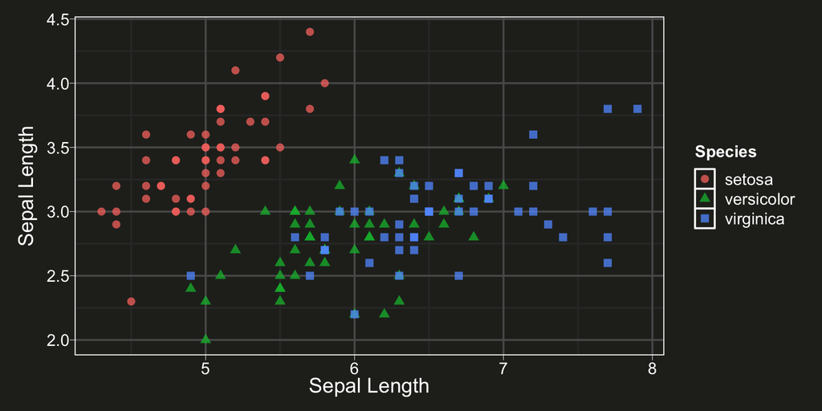

## Font Sizes

```r
p + theme_dyerlab_grey( base_size = 22)
```

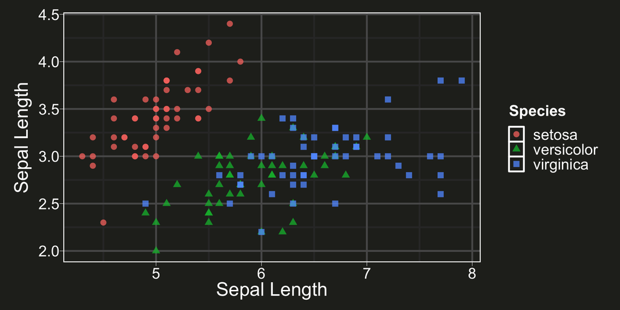

## Globally Set Font Sizes

You can also set the theme and base sizes (and other theme-related items) globally for an entire document/presentation as:

```r
ggplot2::theme_set( theme_bw( base_size=16) )
```

## Boxplots

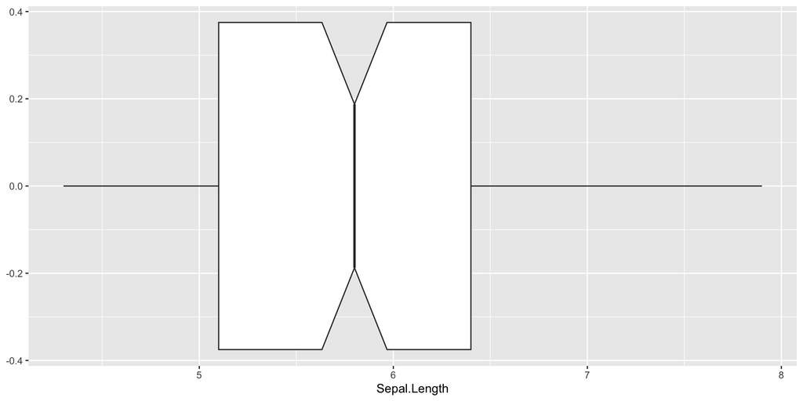

```r
ggplot( iris, aes( x = Sepal.Length) ) +
  geom_boxplot( notch=TRUE )
```

## Species Differences

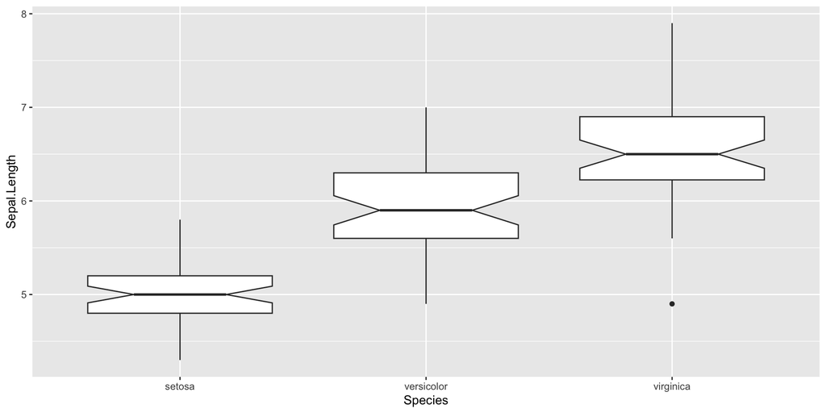

```r
ggplot( iris, aes(x=Species, y=Sepal.Length) )  +
  geom_boxplot( notch=TRUE )
```

## Species Differences Fill Colors

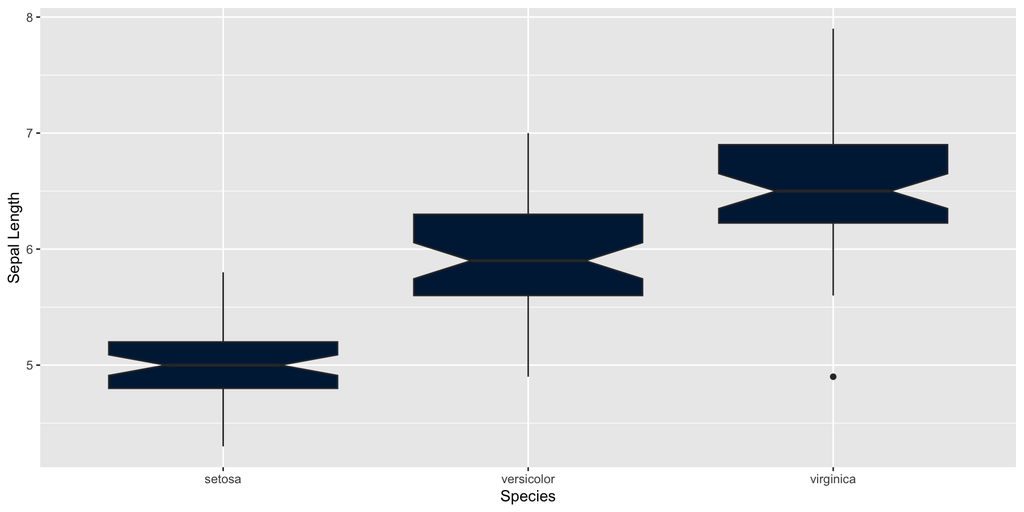

```r
ggplot( iris, aes(x=Species, y=Sepal.Length) )  +
  geom_boxplot( notch=TRUE, fill=c("#002145") ) +
  ylab("Sepal Length")
```

## Species Differences Fill Colors

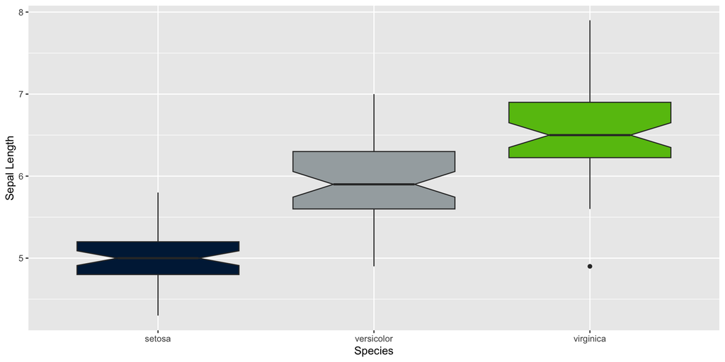

```r
ggplot( iris, aes(x=Species, y=Sepal.Length) )  +
  geom_boxplot( notch=TRUE, fill=c("#002145", "#a5acaf","#66c010") ) +
  ylab("Sepal Length")
```

# Overlays

# Overlaying a Trendline

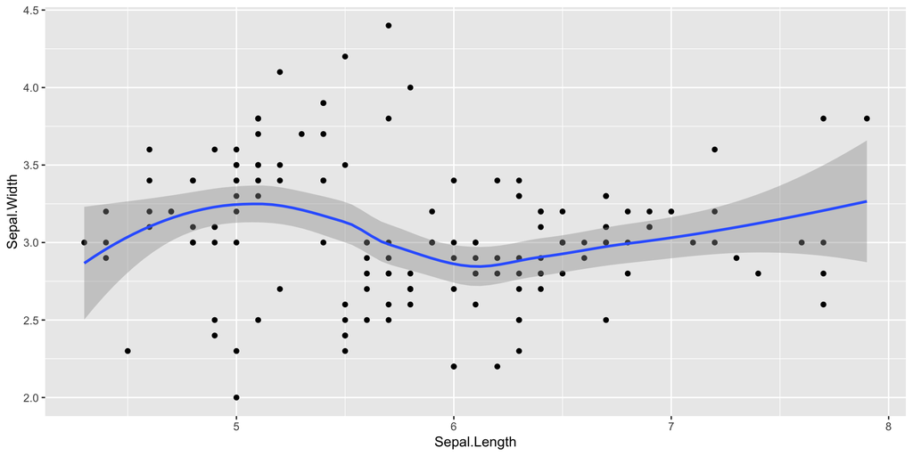

```r
ggplot( iris, aes( x = Sepal.Length, y = Sepal.Width) ) +
  geom_point()  +
  stat_smooth()
```

## Overlaying a Trendline

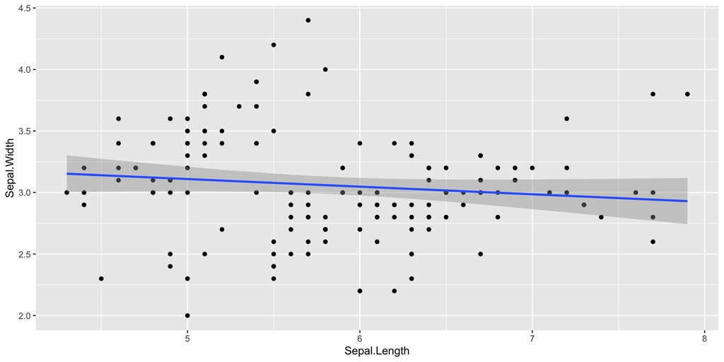

```r
ggplot( iris, aes( x = Sepal.Length, y = Sepal.Width) ) +
  geom_point()  +
  stat_smooth( method="lm", formula = "y ~ x")
```

## Stacking Order

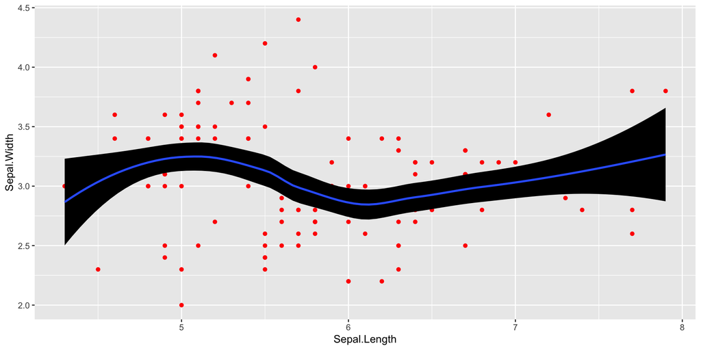

```r
ggplot( iris, aes( x = Sepal.Length, y = Sepal.Width) ) +
  geom_point( color="red")  +
  stat_smooth( fill="black", alpha=1)
```

## Stacking Order

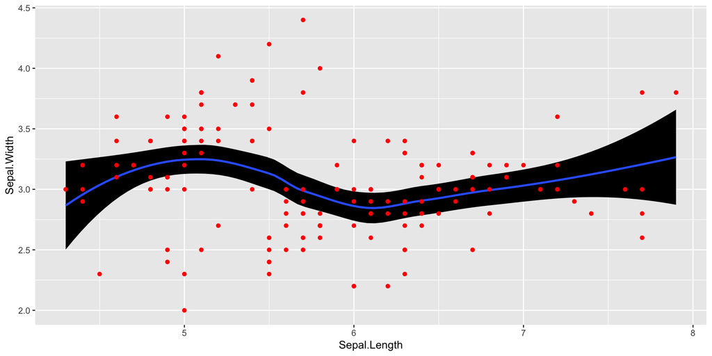

```r
ggplot( iris, aes( x = Sepal.Length, y = Sepal.Width) ) +
  stat_smooth( fill="black", alpha=1) +
  geom_point( color="red")
```

## On-The-Fly Transformations

Customizing the y-axis data format…

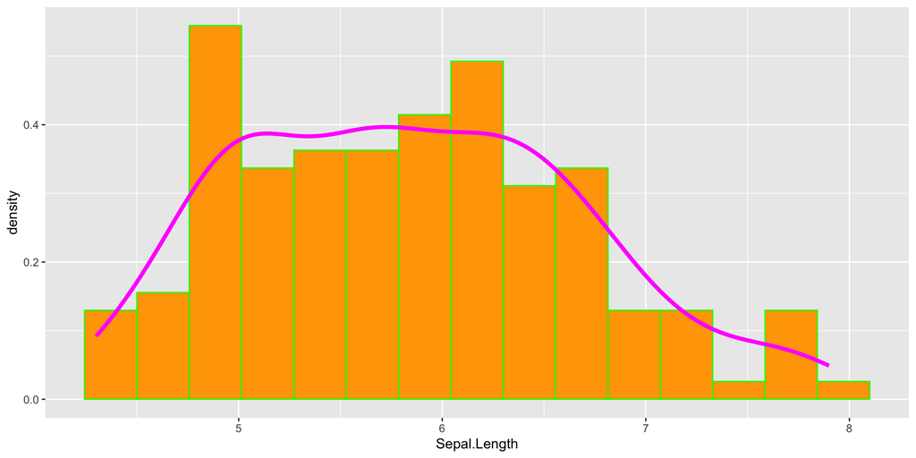

```r
ggplot( iris, aes(x = Sepal.Length) ) +
  geom_histogram( aes( y = ..density.. ),
                  color="green",
                  fill="orange", bins = 15 ) +
  geom_density( color = "magenta", lwd=1.5 )
```

## Textual Overlays

```r
cor_model <- cor.test( iris$Sepal.Length, iris$Sepal.Width)
cor_model
```

```
    Pearson's product-moment correlation

data:  iris$Sepal.Length and iris$Sepal.Width
t = -1.4403, df = 148, p-value = 0.1519
alternative hypothesis: true correlation is not equal to 0
95 percent confidence interval:
 -0.27269325  0.04351158
sample estimates:
       cor
-0.1175698
```

```r
names( cor_model )
```

```
[1] "statistic"   "parameter"   "p.value"     "estimate"    "null.value"
[6] "alternative" "method"      "data.name"   "conf.int"
```

## Formatting as Text

```r
cor.text <- paste( "r = ",
                   format( cor_model$estimate, digits=4),
                   ";\n P = ",
                   format( cor_model$p.value, digits=4 ),
                   sep="" )
cor.text
```

```
[1] "r = -0.1176;\n P = 0.1519"
```

```r
p + geom_text( aes(x=7.25, y=4.25, label=cor.text) )
```

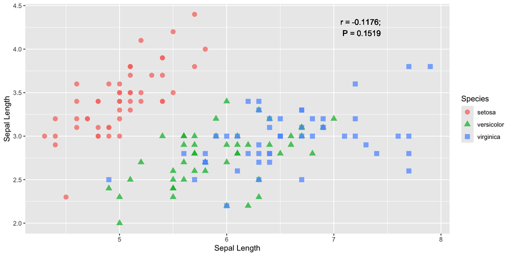

## Labels

```r
iris |>
  group_by( Species ) |>
  summarize( Sepal.Length = mean(Sepal.Length),
             Sepal.Width = mean(Sepal.Width)) -> iris_Centroids
iris_Centroids
```

```
# A tibble: 3 × 3
  Species    Sepal.Length Sepal.Width
  <fct>             <dbl>       <dbl>
1 setosa             5.01        3.43
2 versicolor         5.94        2.77
3 virginica          6.59        2.97
```

## Labels

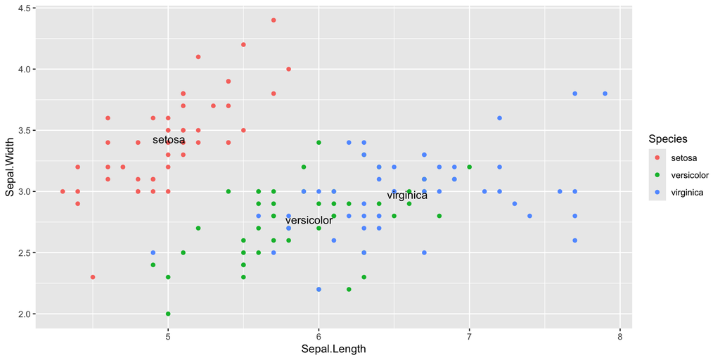

```r
ggplot( iris, aes(Sepal.Length, Sepal.Width) ) +
  geom_point( aes(color=Species) ) +
  geom_text( aes(label=Species), data=iris_Centroids)
```